# Data Visualization

```python
#!pip install plotnine
```

```python
from plotnine import *
from dfply import *
import numpy as np
import pandas as pd
```

## 1. 목적

- `plotnine`은 R의 ggplot2에 기반해 그래프를 그려주는 라이브러리입니다
- 명령어 형식의 `plotnine`의 특징은 ggplot(Grammar of Graphic)의 약자와 같이 grammar 기반의 명령어를 제공하여 문장 형성을 통해 사용자는 데이터 시각화를 가능하게 함
- 지속적인 update를 통해 사용하기 점점 편해짐.
- `plotnine`의 활용 예를 통해 데이터 시각화의 컴포넌트와 실제 데이터와의 연결을 이해함

## 2. 원리 및 용어

- `ggplot` : 메인 함수로 데이터 셋과 표현할 데이터 변수명을 정의함
- `geoms` : 실제 어떤 데이터 시각화를 할지 정의하는 기하학적 객체
  - `geom_point()`, `geom_bar()`, `geom_density()`, `geom_line()`, `geom_area()`
- `aes` : aesthetics (미학적)
  - 형태, 투명도, 색상, 채우기, 라인의 형태 등을 정의
- `scales` : 데이터가 어떻게 표현될지를 정의
  - 연속형, 이산형, log 등

## 3. plotnine의 활용 이해

### 3.1 iris 데이터

[figure not shown]

```python
iris = pd.read_csv('../data/iris.csv')
```

```python
iris.head()
```

|  | Sepal_Length | Sepal_Width | Petal_Length | Petal_Width | Species |
| --- | --- | --- | --- | --- | --- |
| 0 | 5.1 | 3.5 | 1.4 | 0.2 | setosa |
| 1 | 4.9 | 3.0 | 1.4 | 0.2 | setosa |
| 2 | 4.7 | 3.2 | 1.3 | 0.2 | setosa |
| 3 | 4.6 | 3.1 | 1.5 | 0.2 | setosa |
| 4 | 5.0 | 3.6 | 1.4 | 0.2 | setosa |

```python
iris.describe()
```

|  | Sepal_Length | Sepal_Width | Petal_Length | Petal_Width |
| --- | --- | --- | --- | --- |
| count | 150.000000 | 150.000000 | 150.000000 | 150.000000 |
| mean | 5.843333 | 3.057333 | 3.758000 | 1.199333 |
| std | 0.828066 | 0.435866 | 1.765298 | 0.762238 |
| min | 4.300000 | 2.000000 | 1.000000 | 0.100000 |
| 25% | 5.100000 | 2.800000 | 1.600000 | 0.300000 |
| 50% | 5.800000 | 3.000000 | 4.350000 | 1.300000 |
| 75% | 6.400000 | 3.300000 | 5.100000 | 1.800000 |
| max | 7.900000 | 4.400000 | 6.900000 | 2.500000 |

```python
iris.Species.value_counts()
```

```
versicolor    50
setosa        50
virginica     50
Name: Species, dtype: int64
```

### 3.2 Example을 통한 기초 이해

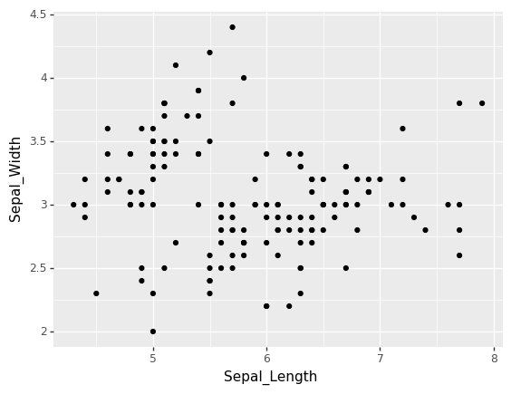

```python
(ggplot(iris, aes("Sepal_Length", "Sepal_Width")) +
    geom_point())
```

### 3.3 기초 구조의 이해

### `ggplot` : 메인 함수로 데이터 셋과 표현할 데이터 변수명을 정의함

- 일종의 백지 위에 그림을 그릴 대상을 정의한 즉, 데이터 시각화를 위한 셋팅 부분임
- 그 이후 어떤 시각화를 할지의 구체적인 데이터 시각화 컴포넌트 대상, 통계모형, 판넬(panels) 등을 백지 상에 레이어 형태로 그림을 그리는 것임

### `aes()` : aesthetics (미학적)

- 형태, 투명도, 색상, 채우기, 라인의 형태 등을 정의

```python
myplot = ggplot(iris, aes("Sepal_Length", "Sepal_Width"))
```

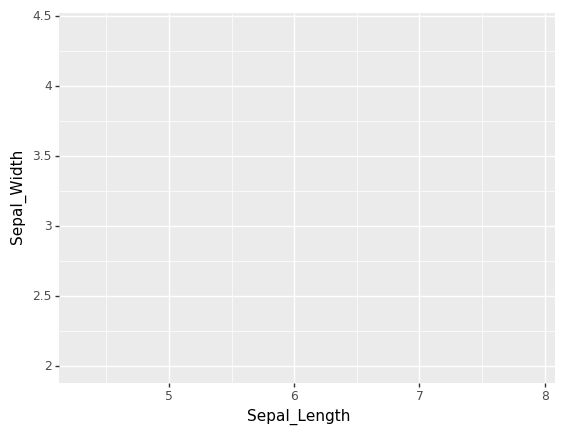

```python
myplot
```

### `geom` : 실제 어떤 데이터 시각화를 할지 정의하는 객체

- `geom_point()`
- `geom_bar()`
- `geom_density()`
- `geom_line()`
- `geom_area()`

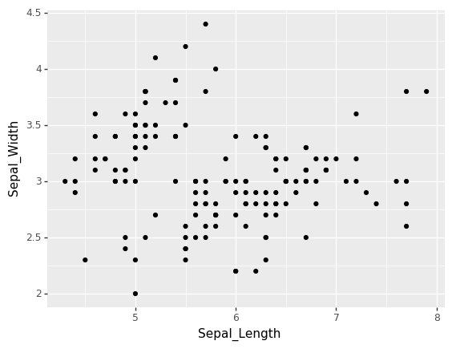

```python
(myplot + geom_point())
```

### 3.4 Further examples

#### 3.4.1 Increase the size of points

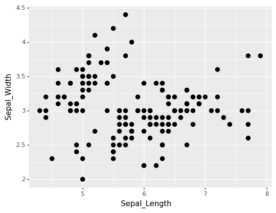

```python
(ggplot(iris, aes("Sepal_Length", "Sepal_Width")) +
 geom_point(size = 3))
```

#### 3.4.2 Add some color

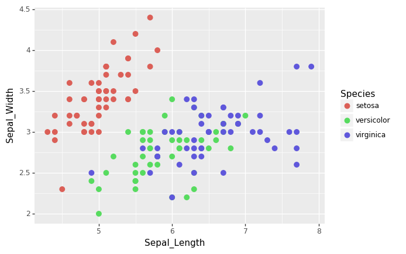

```python
(ggplot(iris, aes("Sepal_Length", "Sepal_Width", color="Species")) +
 geom_point(size = 3))
```

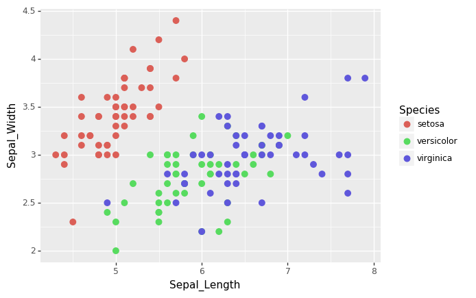

```python
(ggplot(iris, aes("Sepal_Length", "Sepal_Width")) +
geom_point(aes(color = "Species"), size = 3))
```

#### 3.4.3 Differentiate points by shape

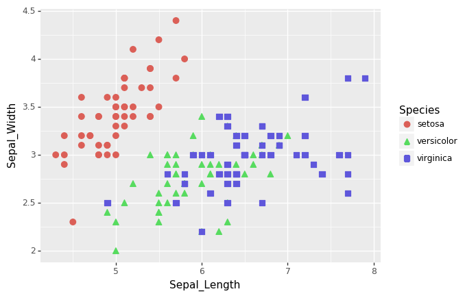

```python
(ggplot(iris, aes("Sepal_Length", "Sepal_Width", color="Species")) +
 geom_point(aes(shape = "Species"), size = 3))
```

[figure not shown]

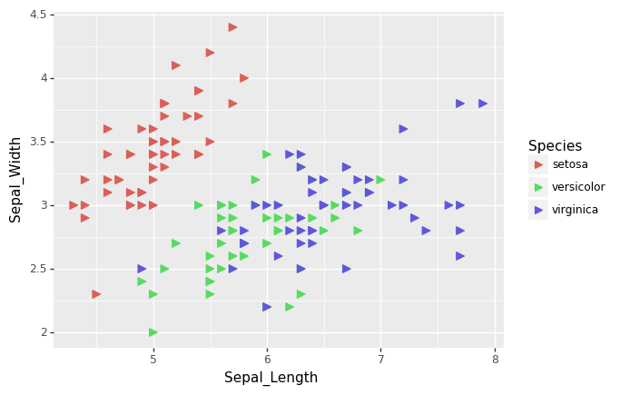

```python
(ggplot(iris, aes("Sepal_Length", "Sepal_Width")) +
 geom_point(aes(color = "Species"), size = 3, shape = ">"))
```

## 4. 데이터 시각화 컴포넌트들

### 4.1 Box plots

#### Box plot을 사용하는 이유

- 많은 데이터를 눈으로 확인하기어려울 때 그림을 이용해 데이터 집합의 범위와 중앙값을 빠르게 확인할 수 있음
- 또한 통계적으로 이상치(outlier)가 있는지 확인
- 상자 수염 그림(Box-and-Whisker Plot) 이라 불리기도 함

[figure not shown]

- **최댓값** : 제 3사분위에서 1.5IQR을 더한 위치
- **제 3사분위(Q3)** : 75% 위치를 의미
- **제 2사분위(Q2)** : 50% 위치로 중앙값(median)을 의미
- **제 1사분위(Q1)** : 25% 위치를 의미
- **최솟값** : 제 1사분위에서 1.5IQR을 뺀 위치
- 최솟값과 최댓값을 벗어나는 위치에 있는 값을 **이상치(Outlier)**이라 함
- **IQR** : 사분 범위 IQR이라는 것은 중앙에 50% 데이터들이 흩어진 정도를 의미( = **Q3 - Q1**)

```python
birthwt = pd.read_csv("../data/birthwt.csv")
```

```python
birthwt.head()
```

|  | low | age | lwt | race | smoke | ptl | ht | ui | ftv | bwt |
| --- | --- | --- | --- | --- | --- | --- | --- | --- | --- | --- |
| 0 | 0 | 19 | 182 | 2 | 0 | 0 | 0 | 1 | 0 | 2523 |
| 1 | 0 | 33 | 155 | 3 | 0 | 0 | 0 | 0 | 3 | 2551 |
| 2 | 0 | 20 | 105 | 1 | 1 | 0 | 0 | 0 | 1 | 2557 |
| 3 | 0 | 21 | 108 | 1 | 1 | 0 | 0 | 1 | 2 | 2594 |
| 4 | 0 | 18 | 107 | 1 | 1 | 0 | 0 | 1 | 0 | 2600 |

```python
birthwt.dtypes
```

```
low      int64
age      int64
lwt      int64
race     int64
smoke    int64
ptl      int64
ht       int64
ui       int64
ftv      int64
bwt      int64
dtype: object
```

- `race`에 따른 신생아의 몸무게 Boxplot을 그리려고함
- 하지만 `race`의 데이터 타입이 숫자형이어서 의도대로 Boxplot이 그려지지 않음

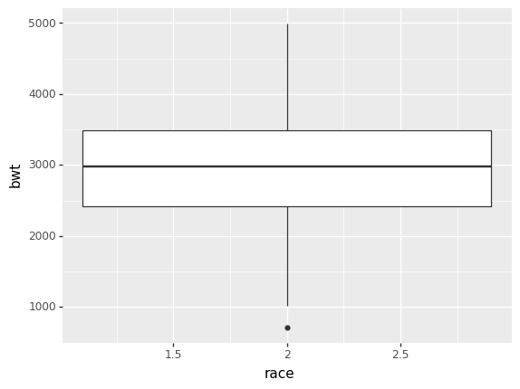

```python
(ggplot(birthwt , aes("race", "bwt")) + geom_boxplot())
```

- `factor()`를 이용하여 범주형 변수로 바꿔준 뒤 시각화

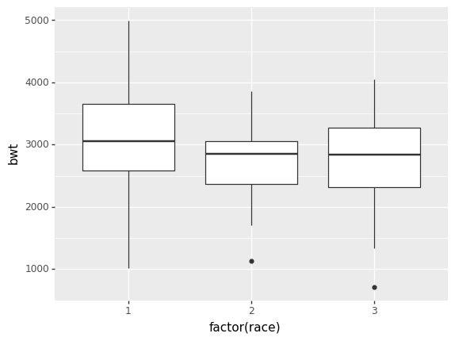

```python
(ggplot(birthwt , aes("factor(race)", "bwt")) + geom_boxplot())
```

- 일일이 색을 채우려고하지만 `race`는 여전히 숫자형 변수임
- `factor()`를 일일이 붙여야하는 불편함이 있음

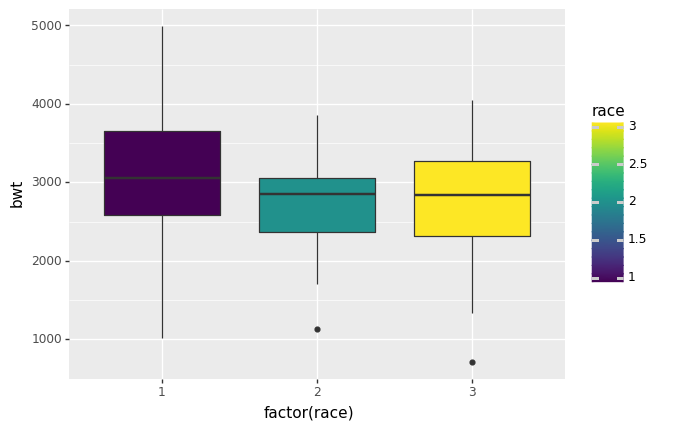

```python
(ggplot(birthwt , aes("factor(race)", "bwt", fill='race')) + geom_boxplot())
```

- 데이터 타입을 `object`로 변경 한 후에 시각화를 진행

```python
birthwt['race'] = birthwt['race'].astype('object')
```

```python
birthwt.dtypes
```

```
low       int64
age       int64
lwt       int64
race     object
smoke     int64
ptl       int64
ht        int64
ui        int64
ftv       int64
bwt       int64
dtype: object
```

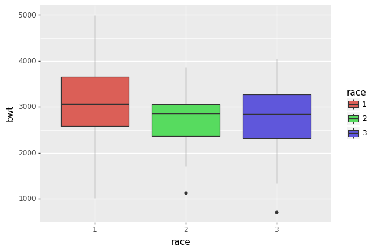

```python
(ggplot(birthwt , aes("race", "bwt", fill='race')) + geom_boxplot())
```

### 4.2 Histograms

#### Histogram 의 특징

- Table 형태의 빈도(개수)를 Graphical하게 표현한 것(도수분포표 -> 시각화)
- `bin` : Histogram의 한 구간

#### Histogram과 막대그래프의 차이

- 막대그래프는 보통 연속되지 않는 자료들을 그래프로 그릴 때 사용
- ex) 사과는 몇 개, 수박은 몇개, 사과와 수박은 서로 연결 할 수 없음
- Histogram은 60 ~ 70점, 70 ~ 80점 처럼 서로 연속된 자료를 나타낼 때 사용
  - 끝값인 70점과 시작점인 70점이 서로 연결

```python
birthwt.head()
```

|  | low | age | lwt | race | smoke | ptl | ht | ui | ftv | bwt |
| --- | --- | --- | --- | --- | --- | --- | --- | --- | --- | --- |
| 0 | 0 | 19 | 182 | 2 | 0 | 0 | 0 | 1 | 0 | 2523 |
| 1 | 0 | 33 | 155 | 3 | 0 | 0 | 0 | 0 | 3 | 2551 |
| 2 | 0 | 20 | 105 | 1 | 1 | 0 | 0 | 0 | 1 | 2557 |
| 3 | 0 | 21 | 108 | 1 | 1 | 0 | 0 | 1 | 2 | 2594 |
| 4 | 0 | 18 | 107 | 1 | 1 | 0 | 0 | 1 | 0 | 2600 |

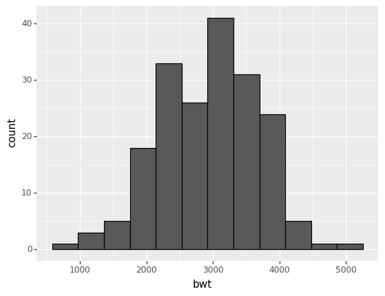

```python
(ggplot(birthwt, aes("bwt")) +
 geom_histogram(color = "black", bins = 12))
```

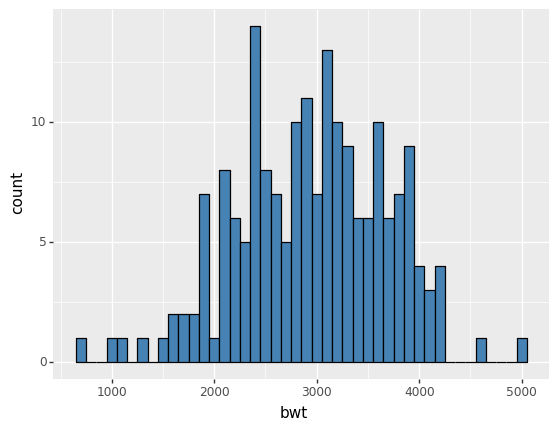

```python
(ggplot(birthwt, aes("bwt")) +
    geom_histogram(binwidth = 100, fill = "steelblue", color = "black"))
```

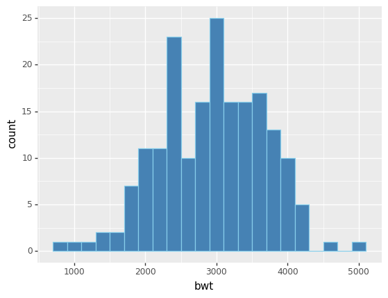

```python
(ggplot(birthwt, aes("bwt")) +
    geom_histogram(binwidth = 200 , fill = "steelblue", color = "skyblue"))
```

### 4.3 Line plots

```python
climate = pd.read_csv("../data/climate.csv")
climate.head()
```

|  | Source | Year | Anomaly 1y | Anomaly 5y | Anomaly 10y | Unc 10y |
| --- | --- | --- | --- | --- | --- | --- |
| 0 | 1 | 1901 | 0.015 | 0.010 | -0.162 | 0.109 |
| 1 | 1 | 1902 | 0.028 | -0.017 | -0.177 | 0.108 |
| 2 | 1 | 1903 | 0.049 | -0.040 | -0.199 | 0.104 |
| 3 | 1 | 1904 | 0.068 | -0.040 | -0.223 | 0.105 |
| 4 | 1 | 1905 | 0.128 | -0.032 | -0.241 | 0.107 |

```python
climate.dtypes
```

```
Source           int64
Year             int64
Anomaly 1y     float64
Anomaly 5y     float64
Anomaly 10y    float64
Unc 10y        float64
dtype: object
```

```python
climate= climate.rename(columns={'Anomaly 1y' : 'Anomaly1y',
                                'Anomaly 5y' : 'Anomaly5y',
                                'Anomaly 10y' : 'Anomaly10y',
                                'Unc 10y' : 'Unc10y',})
```

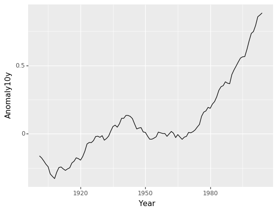

```python
(ggplot(climate, aes("Year", "Anomaly10y")) +
 geom_line())
```

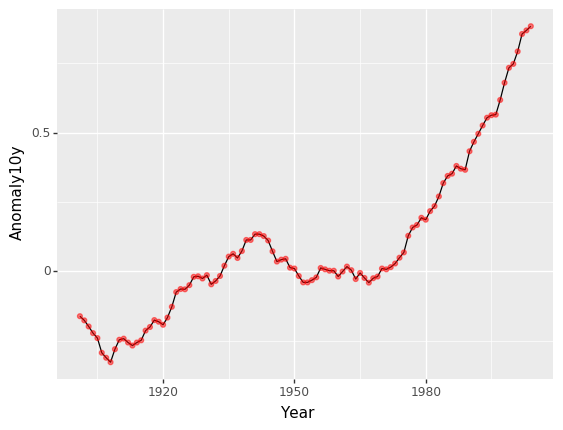

```python
(ggplot(climate, aes("Year", "Anomaly10y")) +
     geom_line() +
     geom_point(color = "red", alpha = 0.5))
```

```python
climate['ymin'] = climate['Anomaly10y'] - climate['Unc10y']
climate['ymax'] = climate['Anomaly10y'] + climate['Unc10y']
climate.head()
```

|  | Source | Year | Anomaly1y | Anomaly5y | Anomaly10y | Unc10y | ymin | ymax |
| --- | --- | --- | --- | --- | --- | --- | --- | --- |
| 0 | 1 | 1901 | 0.015 | 0.010 | -0.162 | 0.109 | -0.271 | -0.053 |
| 1 | 1 | 1902 | 0.028 | -0.017 | -0.177 | 0.108 | -0.285 | -0.069 |
| 2 | 1 | 1903 | 0.049 | -0.040 | -0.199 | 0.104 | -0.303 | -0.095 |
| 3 | 1 | 1904 | 0.068 | -0.040 | -0.223 | 0.105 | -0.328 | -0.118 |
| 4 | 1 | 1905 | 0.128 | -0.032 | -0.241 | 0.107 | -0.348 | -0.134 |

### `geom_ribbon()` : line 주변에 음역지역을 표시

- Y의 최대값과 최소값 사이의 면적을 표시
- aesthetic에 (ymin, ymax)를 필수적으로 요구

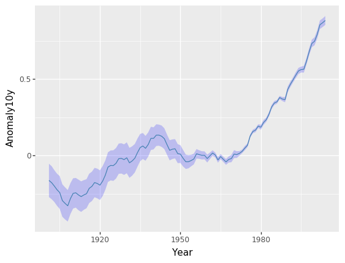

```python
(ggplot(climate, aes('Year', 'Anomaly10y')) +
     geom_ribbon(aes(ymin ='ymin', ymax = 'ymax'), fill = "blue", alpha = .2) +
     geom_line(color = "steelblue"))
```

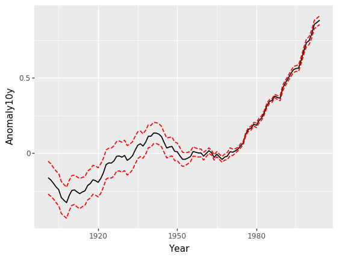

```python
(ggplot(climate, aes('Year', 'Anomaly10y')) +
     geom_line(size = 0.7, color = "black") +
     geom_line(aes('Year', 'ymin'), linetype = "dashed", size = 0.7, color = "red") +
     geom_line(aes('Year', 'ymax'), linetype = "dashed", size = 0.7, color = "red"))
```

### `geom_area()` : `geom_ribbon()`과 비슷하지만 ymin은 0으로 ymax는 Y값 자체로 고정되어 있다는 차이가 있음

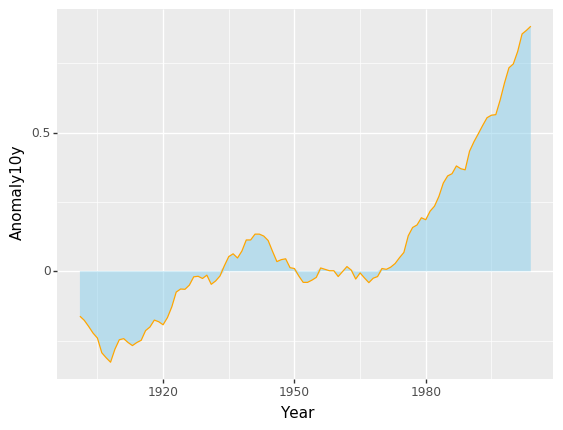

```python
(ggplot(climate, aes('Year', 'Anomaly10y')) +
    geom_area(fill="skyblue", alpha=0.5) +
    geom_line(color = "orange"))
```

### 4.4 Density plots

#### Density plot 이란

- 데이터의 분포를 나타낸 그래프라고 생각하면 됨
- Histogram을 매끄럽게 선으로 표현했다고 생각할 수 있음
- 단, Histogram은 y축이 상대도수나 도수이지만 Density plot은 밀도로 표현

#### Data Description

- carat : weight
- cut : cut scale
- color : color scale
- clarity : clarity scale
- depth : z depth / z * 100
- table : table width / x * 100
- price : price
- x : x
- y : y
- z : z

```python
diamonds.head()
```

|  | carat | cut | color | clarity | depth | table | price | x | y | z |
| --- | --- | --- | --- | --- | --- | --- | --- | --- | --- | --- |
| 0 | 0.23 | Ideal | E | SI2 | 61.5 | 55.0 | 326 | 3.95 | 3.98 | 2.43 |
| 1 | 0.21 | Premium | E | SI1 | 59.8 | 61.0 | 326 | 3.89 | 3.84 | 2.31 |
| 2 | 0.23 | Good | E | VS1 | 56.9 | 65.0 | 327 | 4.05 | 4.07 | 2.31 |
| 3 | 0.29 | Premium | I | VS2 | 62.4 | 58.0 | 334 | 4.20 | 4.23 | 2.63 |
| 4 | 0.31 | Good | J | SI2 | 63.3 | 58.0 | 335 | 4.34 | 4.35 | 2.75 |

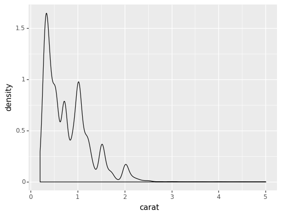

```python
(ggplot(diamonds, aes('carat')) +
    geom_density())
```

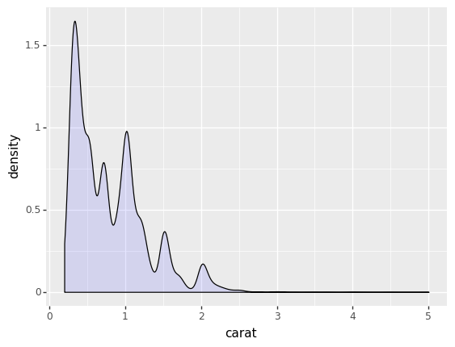

```python
(ggplot(diamonds, aes('carat')) +
    geom_density(fill='blue', alpha=.1))
```

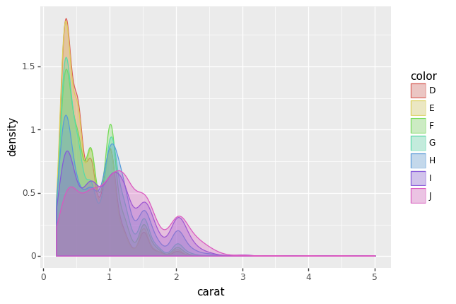

```python
(ggplot(diamonds, aes('carat', fill='color', color='color')) +
    geom_density(alpha=.3))
```

### 4.5 Bar plots

```python
iris.head()
```

|  | Sepal_Length | Sepal_Width | Petal_Length | Petal_Width | Species |
| --- | --- | --- | --- | --- | --- |
| 0 | 5.1 | 3.5 | 1.4 | 0.2 | setosa |
| 1 | 4.9 | 3.0 | 1.4 | 0.2 | setosa |
| 2 | 4.7 | 3.2 | 1.3 | 0.2 | setosa |
| 3 | 4.6 | 3.1 | 1.5 | 0.2 | setosa |
| 4 | 5.0 | 3.6 | 1.4 | 0.2 | setosa |

#### y축 값을 지정하지 않으면 자동적으로 x축 데이터의 빈도를 y값으로 나타낸다.

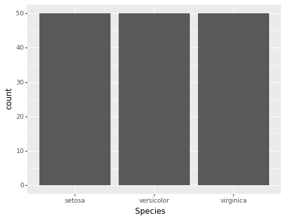

```python
(ggplot(iris, aes(x = 'Species')) +
    geom_bar())
```

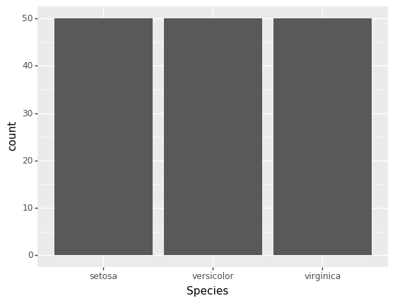

```python
(ggplot(iris, aes(x = "Species")) +
    geom_bar(stat = "count"))
```

### 데이터의 종류를 한 그래프 안에 나눠서 표시해주는 bar 그래프

### `stat = "identity"`

- stat은 Statistic의 약자로 통계를 뜻함
- identitiy는 y축 값의 높이를 데이터 기반으로 정해줄 때 사용

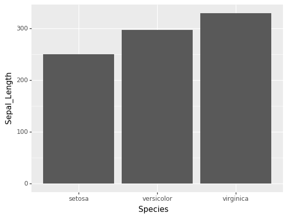

```python
(ggplot(iris, aes('Species', 'Sepal_Length')) +
    geom_bar(stat='identity'))
```

```python
iris.head()
```

|  | Sepal_Length | Sepal_Width | Petal_Length | Petal_Width | Species |
| --- | --- | --- | --- | --- | --- |
| 0 | 5.1 | 3.5 | 1.4 | 0.2 | setosa |
| 1 | 4.9 | 3.0 | 1.4 | 0.2 | setosa |
| 2 | 4.7 | 3.2 | 1.3 | 0.2 | setosa |
| 3 | 4.6 | 3.1 | 1.5 | 0.2 | setosa |
| 4 | 5.0 | 3.6 | 1.4 | 0.2 | setosa |

#### 4.5.1 long data

```python
iris_long = iris.melt(id_vars='Species')
```

```python
iris_long.head()
```

|  | Species | variable | value |
| --- | --- | --- | --- |
| 0 | setosa | Sepal_Length | 5.1 |
| 1 | setosa | Sepal_Length | 4.9 |
| 2 | setosa | Sepal_Length | 4.7 |
| 3 | setosa | Sepal_Length | 4.6 |
| 4 | setosa | Sepal_Length | 5.0 |

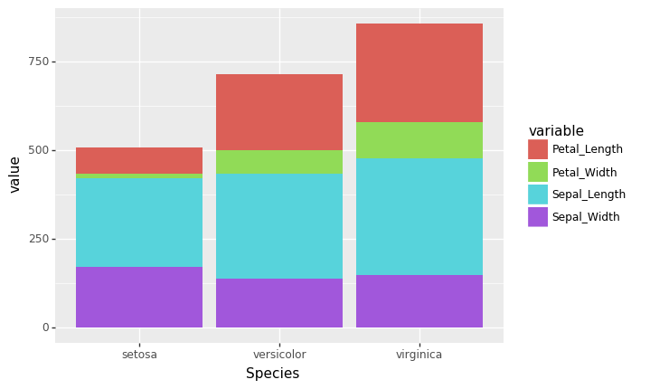

```python
(ggplot(iris_long, aes('Species', 'value', fill='variable')) +
    geom_bar(stat='identity'))
```

### `coord_flip()`

- coord : coordinate의 약자로 조정하고 꾸미는 것을 의미
- flip : 뒤집다의 뜻을 가지고 있음 : x축과 y축을 뒤집어라

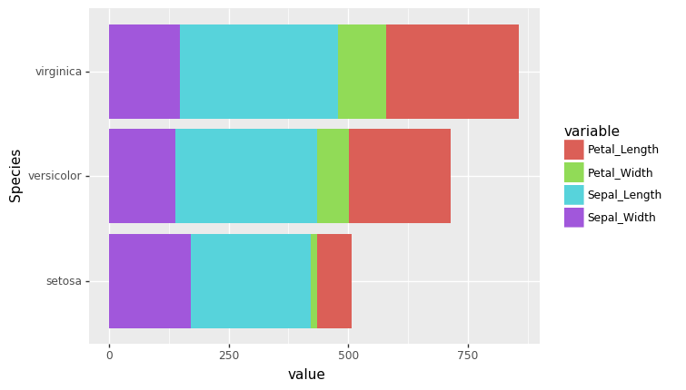

```python
(ggplot(iris_long, aes('Species', 'value', fill='variable')) +
    geom_bar(stat='identity') +
    coord_flip())
```

#### 데이터의 종류를 나눠 따로 표시해주는 그래프

#### `position = "dodge"`

- position은 막대의 위치를 의미
- dodge는 복수의 데이터를 독립적인 막대 그래프로 나란히 표현할때 사용
- 나란히 표시할 막대의 데이터를 fill 함수를 이용해 구분지어줘야 함

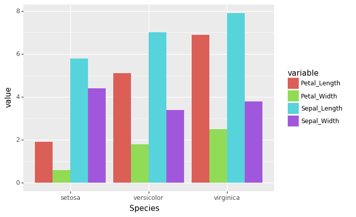

```python
(ggplot(iris_long, aes('Species', 'value', fill='variable')) +
    geom_bar(stat='identity', position='dodge'))
```

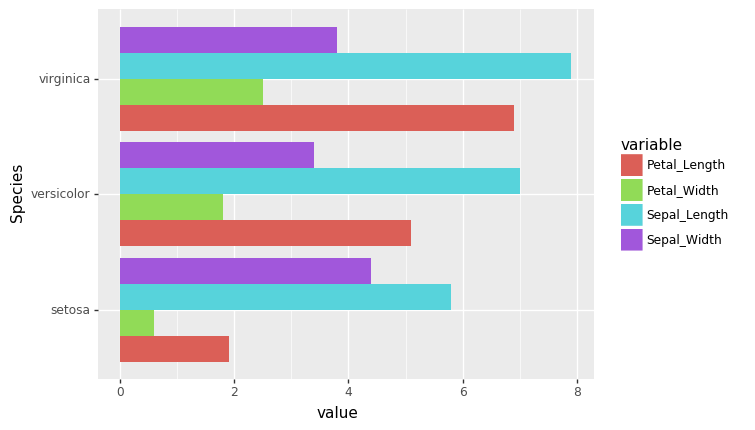

```python
(ggplot(iris_long, aes('Species', 'value', fill='variable')) +
    geom_bar(stat='identity', position='dodge') +
    coord_flip())
```

#### 데이터의 종류를 비율로 표시해주는 bar 그래프

#### `position = "fill"`

- 막대 그래프를 화면에 꽉 채워라, x 값 내의 데이터의 상대적인 비율을 나타낼 때 사용

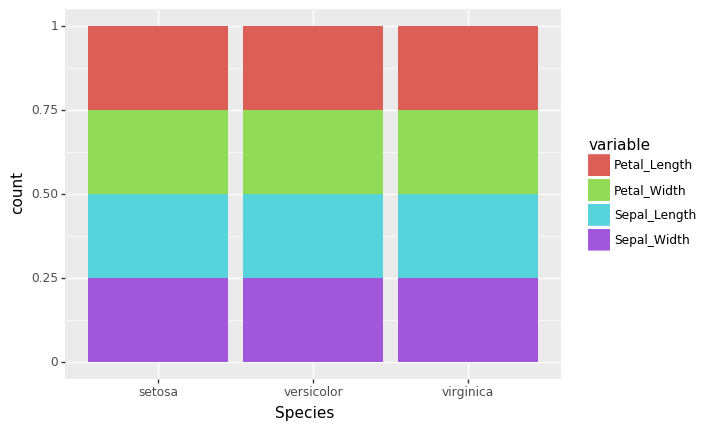

```python
(ggplot(iris_long, aes("Species", fill = "variable")) +
    geom_bar(position = "fill"))
```

```python
diamonds.head()
```

|  | carat | cut | color | clarity | depth | table | price | x | y | z |
| --- | --- | --- | --- | --- | --- | --- | --- | --- | --- | --- |
| 0 | 0.23 | Ideal | E | SI2 | 61.5 | 55.0 | 326 | 3.95 | 3.98 | 2.43 |
| 1 | 0.21 | Premium | E | SI1 | 59.8 | 61.0 | 326 | 3.89 | 3.84 | 2.31 |
| 2 | 0.23 | Good | E | VS1 | 56.9 | 65.0 | 327 | 4.05 | 4.07 | 2.31 |
| 3 | 0.29 | Premium | I | VS2 | 62.4 | 58.0 | 334 | 4.20 | 4.23 | 2.63 |
| 4 | 0.31 | Good | J | SI2 | 63.3 | 58.0 | 335 | 4.34 | 4.35 | 2.75 |

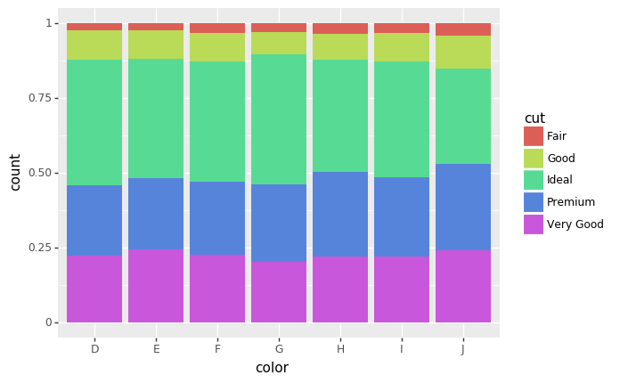

```python
(ggplot(diamonds, aes(x = "color", fill = "cut")) +
    geom_bar(position = "fill"))
```

### scale_fill_brewer(palette = *args)

- 'Blues', 'BuGn', 'BuPu', 'GnBu', 'Greens', 'Greys', 'OrRd', 'Oranges'
- 'PuBu', 'PuBuGn', 'PuRd', 'Purples', 'RdPu', 'Reds', 'YlGn', 'YlGnBu', 'YlOrBr', 'YlOrRd'

[figure not shown]

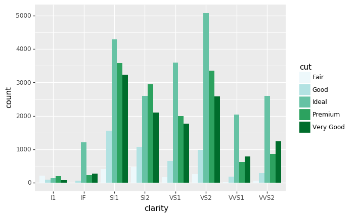

```python
(ggplot(diamonds, aes('clarity', fill='cut')) +
    geom_bar(position='dodge') +
    scale_fill_brewer(palette = "BuGn"))
```

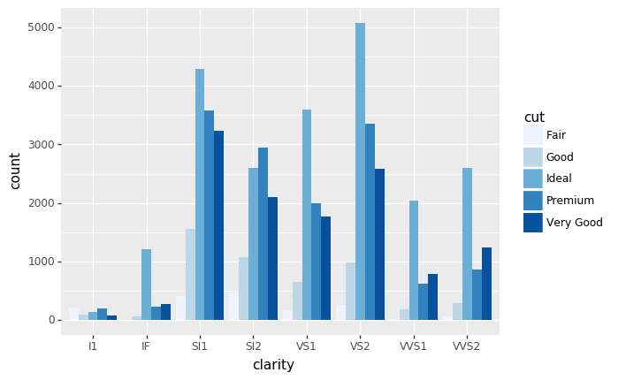

```python
(ggplot(diamonds, aes('clarity', fill='cut')) +
    geom_bar(position='dodge') +
    scale_fill_brewer(palette = "Blues"))
```

[figure not shown]

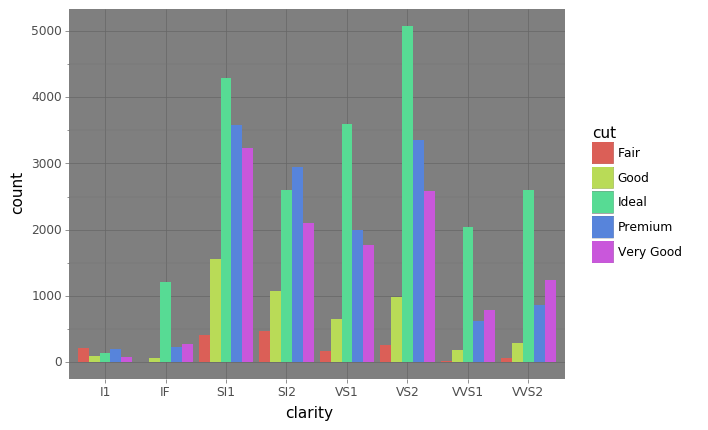

```python
(ggplot(diamonds, aes('clarity', fill='cut')) +
    geom_bar(position='dodge') +
    theme_dark())
```

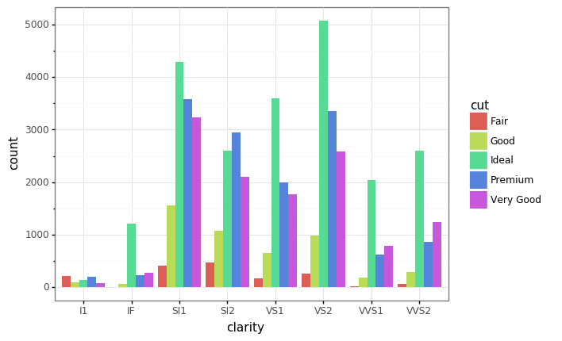

```python
(ggplot(diamonds, aes('clarity', fill='cut')) +
    geom_bar(position='dodge') +
    theme_bw())
```

```python
climate.head()
```

|  | Source | Year | Anomaly1y | Anomaly5y | Anomaly10y | Unc10y | ymin | ymax |
| --- | --- | --- | --- | --- | --- | --- | --- | --- |
| 0 | 1 | 1901 | 0.015 | 0.010 | -0.162 | 0.109 | -0.271 | -0.053 |
| 1 | 1 | 1902 | 0.028 | -0.017 | -0.177 | 0.108 | -0.285 | -0.069 |
| 2 | 1 | 1903 | 0.049 | -0.040 | -0.199 | 0.104 | -0.303 | -0.095 |
| 3 | 1 | 1904 | 0.068 | -0.040 | -0.223 | 0.105 | -0.328 | -0.118 |
| 4 | 1 | 1905 | 0.128 | -0.032 | -0.241 | 0.107 | -0.348 | -0.134 |

```python
climate.dtypes
```

```
Source          int64
Year            int64
Anomaly1y     float64
Anomaly5y     float64
Anomaly10y    float64
Unc10y        float64
ymin          float64
ymax          float64
dtype: object
```

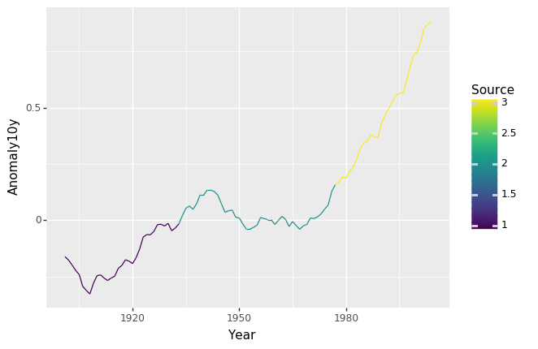

```python
(ggplot(climate, aes("Year", "Anomaly10y", color="Source")) +
 geom_line())
```

```python
climate['sign'] = np.where(climate['Anomaly10y']<0, 'False', 'True')
```

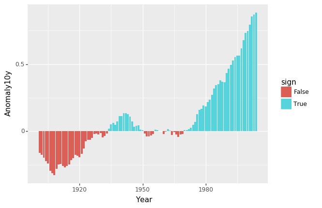

```python
(ggplot(climate, aes('Year', 'Anomaly10y', fill='sign'))
    + geom_bar(stat='identity'))
```

## 5. Trellis graphics

### 5.1 facet_wrap / facet_grid example

- Trellis란 정원에 장미 덩굴 등을 올리기 위한 격가 모양의 틀로 다차원의 데이터를 display하기 위한 일종의 framework임
- 다차원의 데이터를 2차원으로 표현하는데 있어 조건(Categorical Column)으로 격자를 이룬 후 같은 스케일로 동일한 그래프를 고려 비교하는 것이 특징임
- plotnine 패키지에서는 facet 계열 명령어를 통해 Trellis display를 구현할 수 있음
- `facet_wrap()` 은 nrow 설정으로, 몇 줄 혹은 몇 열로 나타나는 것을 지정해 줄 수 있음

```python
from plotnine.data import mtcars
```

#### Data Description

- **name** : Model of Vehicle
- **mpg** : Miles/US Gallon
- **cyl** : Number of cylinders
- **disp** : Displacement
- **hp** : Gross horse power
- **drat** : Rear axle ratio
- **wt** : Weight
- **qsec** : 1/4 mile time
- **vs** : V/S
- **am** : Transmission Type
- **gear** : Number of forward gears
- **carb** : Number of carburetors

```python
mtcars.head()
```

|  | name | mpg | cyl | disp | hp | drat | wt | qsec | vs | am | gear | carb |
| --- | --- | --- | --- | --- | --- | --- | --- | --- | --- | --- | --- | --- |
| 0 | Mazda RX4 | 21.0 | 6 | 160.0 | 110 | 3.90 | 2.620 | 16.46 | 0 | 1 | 4 | 4 |
| 1 | Mazda RX4 Wag | 21.0 | 6 | 160.0 | 110 | 3.90 | 2.875 | 17.02 | 0 | 1 | 4 | 4 |
| 2 | Datsun 710 | 22.8 | 4 | 108.0 | 93 | 3.85 | 2.320 | 18.61 | 1 | 1 | 4 | 1 |
| 3 | Hornet 4 Drive | 21.4 | 6 | 258.0 | 110 | 3.08 | 3.215 | 19.44 | 1 | 0 | 3 | 1 |
| 4 | Hornet Sportabout | 18.7 | 8 | 360.0 | 175 | 3.15 | 3.440 | 17.02 | 0 | 0 | 3 | 2 |

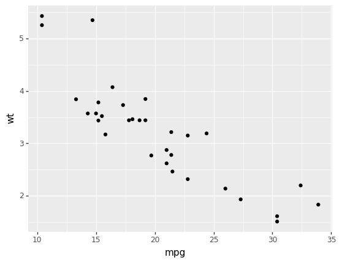

```python
p = ggplot(mtcars, aes('mpg', 'wt')) + geom_point()
p
```

```python
p + facet_wrap('cyl')
```

[output not shown]

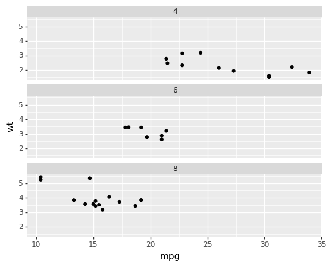

```python
p + facet_wrap('cyl', nrow=3)
```

```python
mtcars.gear.value_counts()
```

```
3    15
4    12
5     5
Name: gear, dtype: int64
```

```python
mtcars.cyl.value_counts()
```

```
8    14
4    11
6     7
Name: cyl, dtype: int64
```

```python
p + facet_grid("~cyl")
```

[output not shown]

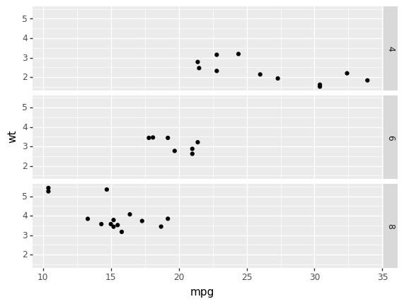

```python
p + facet_grid("cyl~")
```

#### facet_grid(x ~ y)

- x는 행 변수를 y는 열 변수를 지정되며, `facet_wrap()`에 비해 비교하기가 훨씬 쉬운 모습 이다.

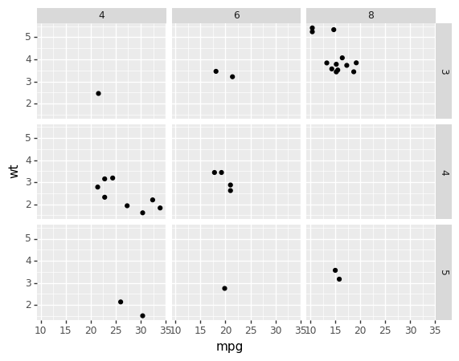

```python
p + facet_grid('gear~cyl')
```

### 5.2 controlling scales in facets

```python
p + facet_wrap('~cyl', scales="fixed")
```

[output not shown]

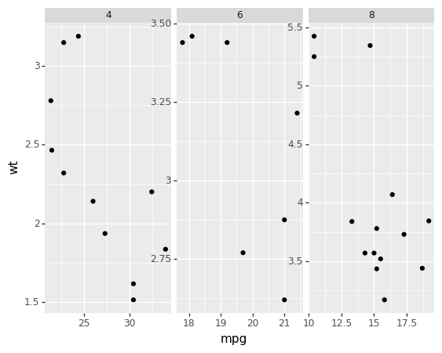

```python
p + facet_wrap('~cyl', scales="free")
```

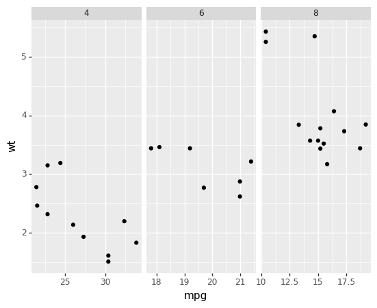

```python
p + facet_wrap('~cyl', scales="free_x")
```

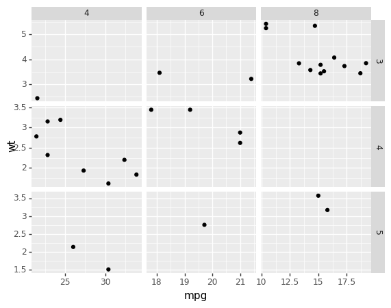

```python
p + facet_grid('gear~cyl', scales="free")
```